# A3: Incarceration

### Introduction

Incarceration rates in the US have been a subject of significant debate, reflecting a broader socio-economic and political dynamic. One area I would like to analyze is the difference in incarceration rates between men and women. Understanding these differences may shed light on the various factors that contribute to incarceration and how they might affect different segments of the population.

Specifically, I would like to examine how these rates vary between all of the US and Washington State. As a woman myself, I am particularly curious in understanding these disparities. By analyzing national trends and comparing them to data from Washington State, I hope to uncover whether the criminal justice system operates differently for men and women and how these differences manifest across different types of correctional facilities.

### Summary Information

There are notable differences in incarceration rates between the national average and Washington State. Nationally, the mean prison population for all counties is `55563.23`, with female inmates accounting for `28017.49`, and male inmates accounting for `27545.74`.

In Washington State, however, the average prison population is significantly lower at `371.83`, with a female population of `64.01`, and a male population of `716.77`.

This discrepancy is further highlighted by the ratios: nationally, the ratio of female to total inmates is`0.5`, while in Washington State, it is much lower at`0.17`. Conversely, the ratio of male to total inmates nationally is `0.5`, but in Washington State, it is significantly higher at `1.93`. These differences suggest a substantial variation in gender distribution within the prison populations between the national average and Washington State.

### The Dataset

**Who collected the data?**

The Vera Institute of Justice

**How was the data collected or generated?**

The data was collected through the Bureau of Justice Statistics. The Bureau of Justice Statistics collects data through the COJ (Census of Jails) and the ASJ (Annual Survey of Jails). The COJ collects data on the number of people in jail, while the ASJ collects data on the number of people in prison. This project was by the Robert W. Wilson Charitable Trust. Additionally, with the help of a grant from the MacArthur Foundation Safety and Justice Challenge, the Vera Institute of Justice was able to collect data on the number of people in jail and prison in the United States.

**Why was the data collected?**

The data was collected to get a more detailed look at incarceration. While state-level data gives a broad view, it fails to capture the detailed causes and consequences of incarceration as county officials can make key decisions about who goes to jail and for how long. Therefore, county-level data helps us better understand the reasons behind high incarceration rates in the U.S.

**How many observations (rows) are in your data?**

In the broad prison data set there are `153811` and in the Washington State data set there are `1131` rows.

**How many features (columns) are in the data?**

In the broad prison data set there are `36` and in the Washington State data set there are `23` columns.

**What, if any, ethical questions or questions of power do you need to consider when working with this data?**

When working with incarceration data, ethical questions to consider include privacy concerns and the potential stigmatization of individuals based on their criminal history. It’s crucial to handle the data with sensitivity and respect. Additionally, questions of power involve recognizing how the criminal justice system’s inherent biases and disparities may be reflected in the data. These systemic issues need to be carefully considered and addressed in the analysis.

**What are possible limitations or problems with this data? (at least 200 words)** One limitation of this data is that it may not capture the full scope of the criminal justice system’s impact on individuals. For example, the broad prison population data lacks detailed demographic information, such as race, ethnicity, and socioeconomic status. This absence makes it challenging to analyze and understand the disparities and biases present within the system. Without these details, it is difficult to identify which groups are disproportionately affected by incarceration and to what extent systemic racism or other forms of discrimination contribute to these disparities.

In contrast, the Washington State data does include some demographic information, but it is still limited. While it provides a better understanding of the local population, it may not be comprehensive enough to draw conclusive insights about broader trends. The limited extent of demographic data in Washington State can restrict the ability to conduct in-depth analysis of how various factors, such as race and economic background, influence incarceration rates.

Lastly, while this county-level data does help bridge some of these gaps by offering a more detailed view than state-level, it still has limitations. Like the Vera Institute mentioned themselves, county officials, judges, and prosecutors play a significant role in determining incarceration rates. Their discretion can lead to variability in incarceration practices across regions. This variability is not always apparent in the data, making it difficult to fully understand the underlying causes of differences in incarceration rates.

### Trends Over Time Chart

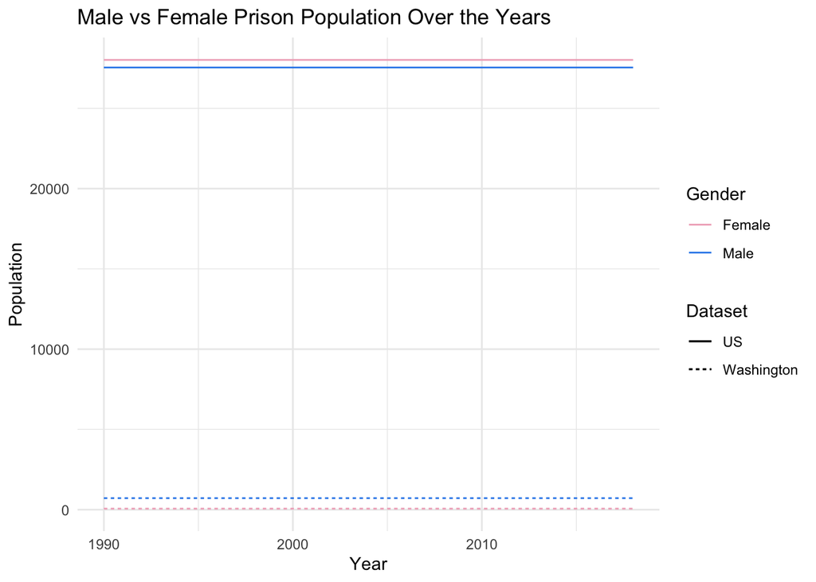

The chart above shows the trend of male vs female population in both Washington State (dotted line) and in the national level (solid line) over the years. Although I could do a static comparison through finding the averages of each variable, I wanted to see if there were any changes in the overall trends.The chart reveals that nationally, there are actually a greater female population. However, in Washington state, there is a greater male population. It should be noted that the gap is also bigger in Washington state than it is nationally. This suggests that just looking at the averages alone may not give the full picture of the incarceration rates, as the national averages showed a 50-50 ratio for male vs female population.

### Variable Comparison Chart

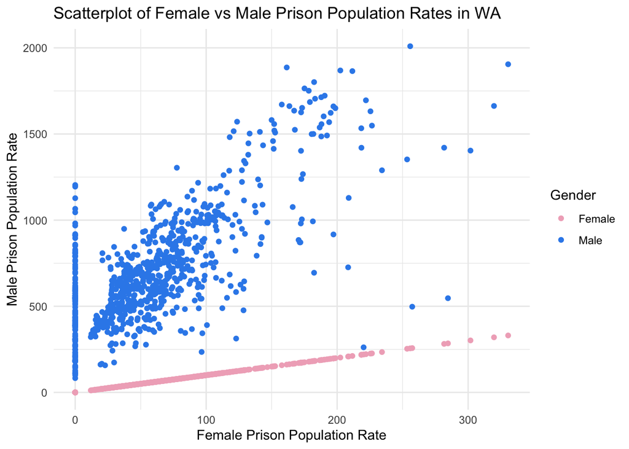

This chart displays the relationship between female and male prison population rates in Washington state. I wanted to include this chart specifically as this comparison helps to identify potential correlations or patterns in my home state’s prison population dynamics between genders. Regarind findings, there seems to be a general positive correlation between the male and female prison population rates. As the female prison population rate increases, the male prison population rate also tends to increase. Additionally, the distribution of data points suggests that while there is a correlation, the male prison population rate tends to vary much more than the female rate, as indicated by the wider spread of points along the male rate axis and waiter outliers.

### Map

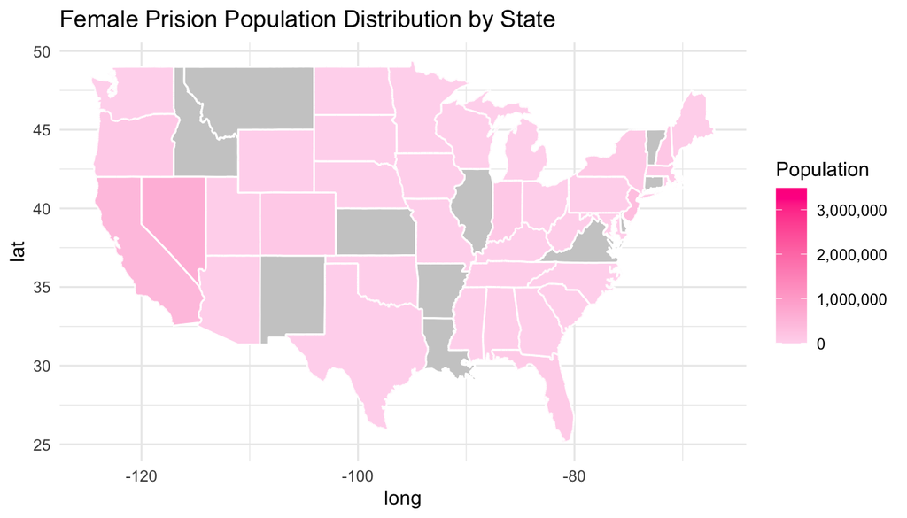

However, I should note that I think my map code is a bit off, as it oddly doesn’t include some states that do have data like Idaho… But, the rest of the data is correct.